# All color palettes

Hansjoerg Neth

2024-05-01

[figure not shown]

This vignettes provides an overview of the **color palettes** provided by the **unicol** package. (See the Using color palettes vignette for information on how to use the **unicol** color palettes.)

We install and load the **unicol** package to get started:

```r
# install.packages('unicol')  # install unicol from CRAN client
library('unicol')             # load the package
```

## Overview

The **unicol** package currently provides **269 color palettes** from **116 institutions**.

**Table 1** provides an overview of all included institutions and color palettes. Clicking on the name of a color palette opens the corresponding page of the [online reference](https://hneth.github.io/unicol/dev//reference/).

Overview of 269 unicol palettes (from 116 institutions).

|  | University / Institution | Country | Color palette | N of colors |
| --- | --- | --- | --- | --- |
| 1 | [Aalto University](https://www.aalto.fi/fi) | Finland | [aalto_1](https://hneth.github.io/unicol/dev/reference/aalto_1.html) | 3 |
| 2 | [Aalto University](https://www.aalto.fi/fi) | Finland | [aalto_2](https://hneth.github.io/unicol/dev/reference/aalto_2.html) | 6 |
| 3 | [Aarhus University](https://www.au.dk) | Denmark | [aarhus](https://hneth.github.io/unicol/dev/reference/aarhus.html) | 20 |
| 4 | [Aberystwyth University](https://aber.ac.uk/en/) | UK | [aberystwyth_1](https://hneth.github.io/unicol/dev/reference/aberystwyth_1.html) | 2 |
| 5 | [Aberystwyth University](https://aber.ac.uk/en/) | UK | [aberystwyth_2](https://hneth.github.io/unicol/dev/reference/aberystwyth_2.html) | 6 |
| 6 | [Arizona State University](https://www.asu.edu) | USA | [asu_1](https://hneth.github.io/unicol/dev/reference/asu_1.html) | 4 |
| 7 | [Arizona State University](https://www.asu.edu) | USA | [asu_2](https://hneth.github.io/unicol/dev/reference/asu_2.html) | 7 |
| 8 | [Arizona State University](https://www.asu.edu) | USA | [asu_3](https://hneth.github.io/unicol/dev/reference/asu_3.html) | 9 |
| 9 | [Australian National University](https://www.anu.edu.au) | Australia | [anu_1](https://hneth.github.io/unicol/dev/reference/anu_1.html) | 4 |
| 10 | [Australian National University](https://www.anu.edu.au) | Australia | [anu_2](https://hneth.github.io/unicol/dev/reference/anu_2.html) | 4 |
| 11 | [Boston University](https://www.bu.edu) | USA | [bu](https://hneth.github.io/unicol/dev/reference/bu.html) | 2 |
| 12 | [Brown University](https://www.brown.edu) | USA | [brown_1](https://hneth.github.io/unicol/dev/reference/brown_1.html) | 4 |
| 13 | [Brown University](https://www.brown.edu) | USA | [brown_2](https://hneth.github.io/unicol/dev/reference/brown_2.html) | 4 |
| 14 | [California Institute of Technology](https://www.caltech.edu) | USA | [caltech_1](https://hneth.github.io/unicol/dev/reference/caltech_1.html) | 8 |
| 15 | [California Institute of Technology](https://www.caltech.edu) | USA | [caltech_2](https://hneth.github.io/unicol/dev/reference/caltech_2.html) | 5 |
| 16 | [California Institute of Technology](https://www.caltech.edu) | USA | [caltech_3](https://hneth.github.io/unicol/dev/reference/caltech_3.html) | 8 |
| 17 | [Cardiff University](https://www.cardiff.ac.uk) | UK | [cardiff_1](https://hneth.github.io/unicol/dev/reference/cardiff_1.html) | 12 |
| 18 | [Cardiff University](https://www.cardiff.ac.uk) | UK | [cardiff_2](https://hneth.github.io/unicol/dev/reference/cardiff_2.html) | 9 |
| 19 | [Carnegie Mellon University (CMU)](https://www.cmu.edu) | USA | [cmu_1](https://hneth.github.io/unicol/dev/reference/cmu_1.html) | 5 |
| 20 | [Carnegie Mellon University (CMU)](https://www.cmu.edu) | USA | [cmu_2](https://hneth.github.io/unicol/dev/reference/cmu_2.html) | 6 |
| 21 | [Carnegie Mellon University (CMU)](https://www.cmu.edu) | USA | [cmu_3](https://hneth.github.io/unicol/dev/reference/cmu_3.html) | 6 |
| 22 | [Columbia University](https://www.columbia.edu) | USA | [columbia_1](https://hneth.github.io/unicol/dev/reference/columbia_1.html) | 2 |
| 23 | [Columbia University](https://www.columbia.edu) | USA | [columbia_2](https://hneth.github.io/unicol/dev/reference/columbia_2.html) | 6 |
| 24 | [Columbia University](https://www.columbia.edu) | USA | [columbia_3](https://hneth.github.io/unicol/dev/reference/columbia_3.html) | 5 |
| 25 | [Concordia University](https://www.concordia.ca) | Canada | [concordia_1](https://hneth.github.io/unicol/dev/reference/concordia_1.html) | 8 |
| 26 | [Concordia University](https://www.concordia.ca) | Canada | [concordia_2](https://hneth.github.io/unicol/dev/reference/concordia_2.html) | 4 |
| 27 | [Concordia University](https://www.concordia.ca) | Canada | [concordia_3](https://hneth.github.io/unicol/dev/reference/concordia_3.html) | 9 |
| 28 | [Concordia University](https://www.concordia.ca) | Canada | [concordia_4](https://hneth.github.io/unicol/dev/reference/concordia_4.html) | 5 |
| 29 | [Cornell University](https://www.cornell.edu) | USA | [cornell_1](https://hneth.github.io/unicol/dev/reference/cornell_1.html) | 3 |
| 30 | [Cornell University](https://www.cornell.edu) | USA | [cornell_2](https://hneth.github.io/unicol/dev/reference/cornell_2.html) | 3 |

[output cut: 239 more lines]

### Illustration

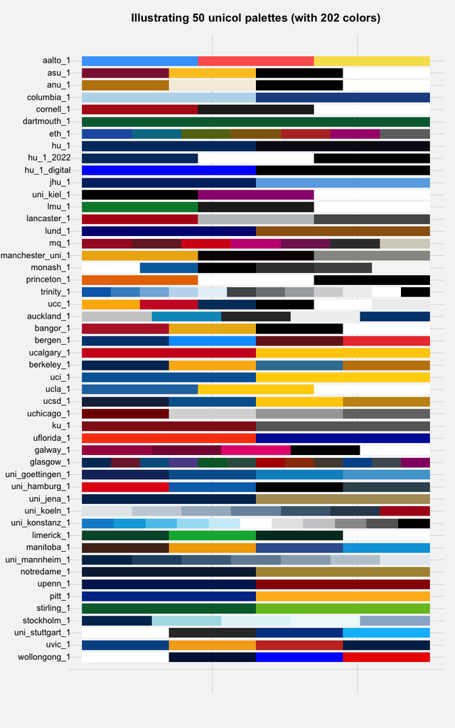

**Figure 1:** Examples of **unicol** color palettes.

## Your color palettes

The current range of color palettes included in **unicol** is selective and incomplete. We are always happy to include new color palettes and institutions from all over the world.

If you are missing a color palette, you can easily create it. For instructions how this can be done, please see the documentation of the `newpal()` function (of the **unikn** package). The vignette on [Institutional colors](https://hneth.github.io/unikn/articles/inst_colors.html) provides a corresponding example.

**Call for contributions: Collecting color palettes**

- Are you using the **unikn** color functions to create **your own color palettes**?

[figure not shown]

If you do create a new color palette, **please let us know** (on this [GitHub issue](https://github.com/hneth/unicol/issues/30)) so that we can include it in future versions of the **unicol** package. To enable us to verify and provide credit to your contributions, please send us the following information:

1. your code (e.g., the `newpal()` command creating your color palette),
2. your reference or source information (e.g., some URL with color definitions),
3. your name and some contact information (e.g., an Email address).

We’re looking forward to **your inputs and contributions** (at this [GitHub issue](https://github.com/hneth/unicol/issues/30))!

## Vignettes

[figure not shown]

The following vignettes provide an overview of and examples for using the **unicol** color palettes:

| Nr. | Vignette | Content |
| --- | --- | --- |
| 1. | All color palettes | The color palettes of the **unicol** R package |
| 2. | Using color palettes | Recipes for using the **unicol** color palettes |